# Visualization Practices/Mistakes

Nick Strayer

May 17, 2016

## Outline

- What to use?
- Common Mistakes/fixes
  - Pie Charts
  - Word Clounds
  - Trucated Axes
  - Multiple Axes
  - Information Overload
  - The Third Dimension
- Ggplot
  - Weaknesses
  - Strengths
  - Bottom Line
- New Tools/Libraries
  - plotly
  - html widgets
  - Manhattan Plots
- Complex Visualizations/Dashboards
  - Ggmatrix
  - Don’t go crazy
  - Plan Ahead.
- Beauty Vs. Clarity.

## What to use?

> “The best camera is the one that’s with you.” –Chase Jarvis.
- Jeff Leek has a [fantastic article](http://simplystatistics.org/2016/02/11/why-i-dont-use-ggplot2/) on his blog about this issue.
- Ultimately it comes down to what you know. You can do an absolutely amazing amount in most tools (even excel) so do what you like best.
- For most people in R the choice is Ggplot vs Base. I mostly use Ggplot because it’s what I am the most familiar with (and it has nice defaults (more on this later)).

## Common Mistakes

A lot of data visualization is common sense, but some of it isn’t. These are a few of the examples of mistakes made very frequently by visualization practitioners.

### The Pie Chart

Okay, let’s get the elephant out of the room first. The pie chart elicitaes a similar response in a dataviz person as a computer scientist’s prediction algorithm to a statistician. Initially claims of blashpheme but sometimes upon closer inspection grudging respect.

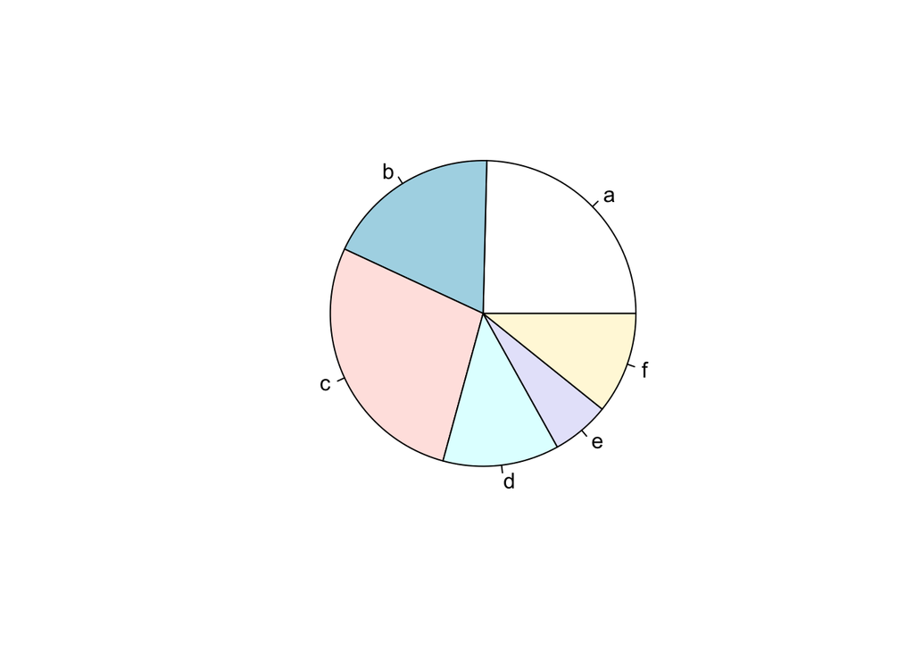

```r
data = data.frame(
  val  = c( 8,   6,   9,   4,   2,  3.5),
  labs = c("a", "b", "c", "d", "e", "f")
)

pie(data$val, data$labs)
```

So why all the ire?

Humans have a very hard time interpreting angles, and that’s how a pie chart encodes the data. Looking at the chart above we know that d and f are 0.5 apart, or f is only 87.5% of the size of d, but upon initial inspection the average user would probably say they are the same.

So let’s fix it.

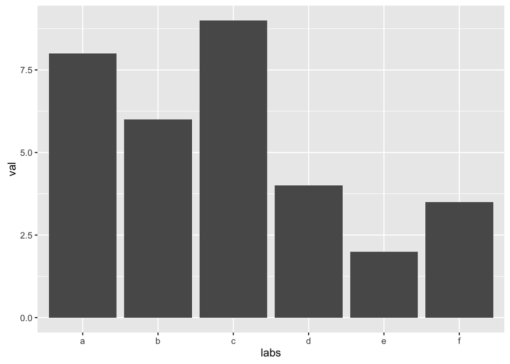

```r
library(ggplot2)
ggplot(data, aes(y = val, x = labs)) + geom_bar(stat = "identity")
```

Now we can clearly see that f is smaller than d

Is it all warrented?